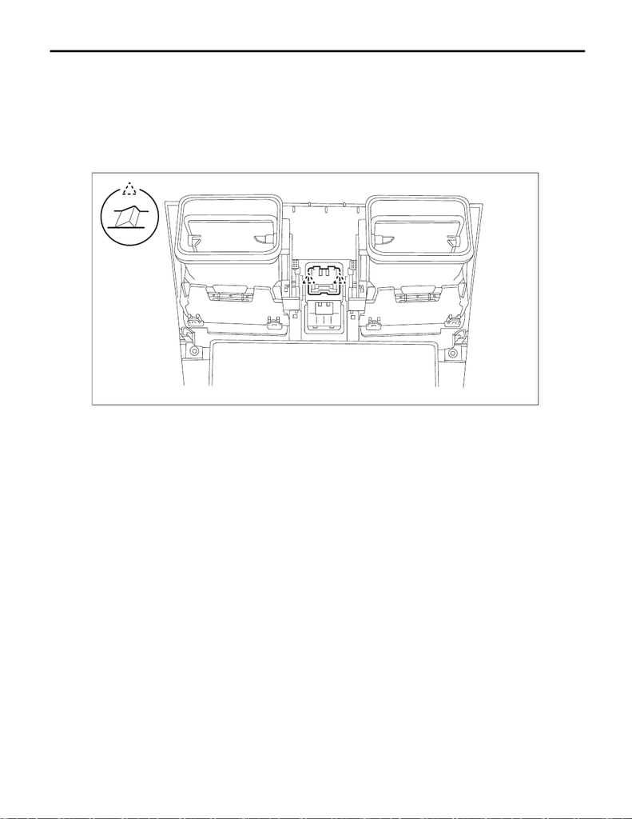

LI-31

Hazard Switch

LIGHTING SYSTEM

16.Hazard Switch

A: REMOVAL

1) Disconnect the ground cable from battery. <Ref. to NT-5, BATTERY, NOTE, Note.>

NOTE:

For models other than STI model, disconnect the ground terminal from battery sensor.

2) Remove the panel center assembly. <Ref. to EI-66, REMOVAL, Center Console.>

3) Release the claws, and then remove the switch - hazard.

B: INSTALLATION

CAUTION:

After installing the panel center assembly, check that the air vent grille of the panel center assembly

is inserted correctly into the air vent duct.

1) Install the switch - hazard.

2) Install the panel center assembly.

3) Connect the battery ground terminal. <Ref. to NT-5, BATTERY, NOTE, Note.>

NOTE:

For models other than STI model, connect the ground terminal to battery sensor.

LI-01718

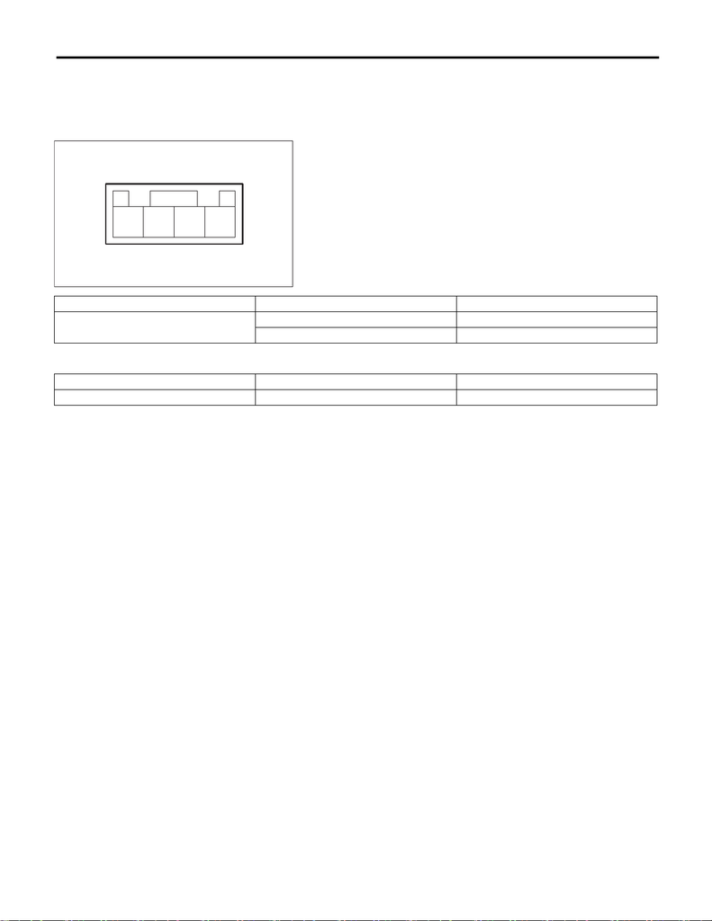

LI-32

Hazard Switch

LIGHTING SYSTEM

C: INSPECTION

1) Measure the resistance between connector terminals.

Preparation tool:

Circuit tester

2) Apply battery voltage between the connector terminals to check the lighting condition of the light.

3) Replace the switch - hazard if the inspection result is not within the standard value.

LI-01719

4 3 2 1

Terminal No. Inspection conditions Standard

2 — 3

Switch OFF 1 MΩ or more

Switch ON Less than 1 Ω

Terminal No. Inspection conditions Specification

4 (+) — 1 (–) Apply battery voltage. Light ON